# Lab 18: Inference for the Mean

## Instructions

Below you will find several empty R code scripts and answer prompts. Your task is to fill in the required code snippets and answer the corresponding questions.

## Teacher Salary

The available variables are

- base: Base annual salary, in dollars
- degree: Highest educational degree attained: BA (Bachelor’s) or MA (Master’s)
- years: Number of years employeed

Using the mean function, what is the average base pay of all teachers in the dataset?

```
## [1] 56937.61
```

Fit a model for the mean of the base pay variable using lm_basic. Save the model as an object called “model”:

Using a call to `reg_table`, find the mean implied by the model:

```
##
## Call:
## lm_basic(formula = base ~ 1, data = teachers)
##
## Residuals:
##    Min     1Q Median     3Q    Max
## -21511  -5764   2976   8422  11292
##
## Coefficients:
##             Estimate
## (Intercept)    56938
##
## Residual standard error: 9029 on 69 degrees of freedom
```

Does the mean agree with your answer to question 2?

Add a 95% confidence interval to the regression table.

```
##
## Call:
## lm_basic(formula = base ~ 1, data = teachers)
##
## Residuals:
##    Min     1Q Median     3Q    Max
## -21511  -5764   2976   8422  11292
##
## Coefficients:
##             Estimate 2.5 % 97.5 %
## (Intercept)    56938 54785  59091
##
## Residual standard error: 9029 on 69 degrees of freedom
```

Draw a histogram of the base salary values for the entire dataset.

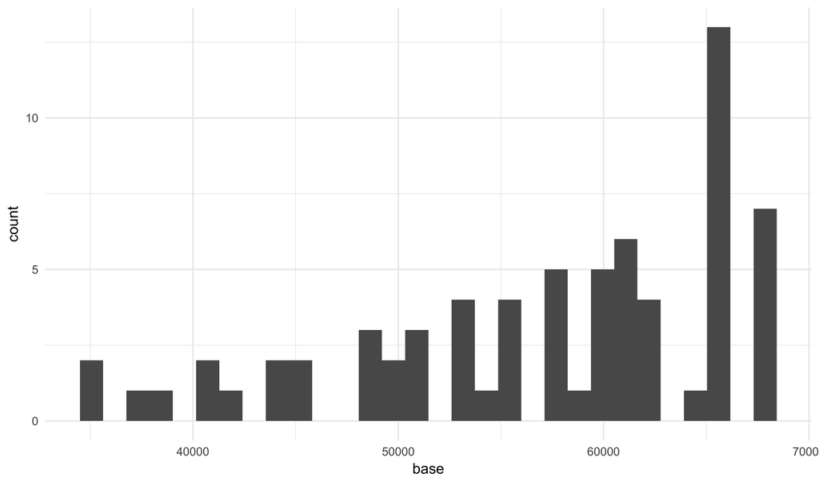

Do most of the salary values fall within the range given in question 5? Why or why not?

**No, because the confidence intervals are not trying to capture the data but the theoretical mean of the data. As we collect more and more data, the unceirtanty of the true mean gets more narrow.** :

Use the filter command to construct a new dataset called `masters` consisting of just those teachers with a masters degree.

Compute a 95% confidence interval for the mean pay of teachers with a master’s degree. Does this range intersect the one you had in question 5?

```
##
## Call:
## lm_basic(formula = base ~ 1, data = masters)
##
## Residuals:
##      Min       1Q   Median       3Q      Max
## -16098.7  -5673.2    958.3   5698.8  10436.3
##
## Coefficients:
##             Estimate 2.5 % 97.5 %
## (Intercept)    57794 54890  60697
##
## Residual standard error: 7915 on 30 degrees of freedom
```

## Murder Data

Now load the following dataset containing all murders that have occurred in London from 1 January 2006 to 7 September 7 2011.

The available variables are:

- age: age of the victim in years
- year: year of the murder
- borough: the London borough in which the murder took place

Find an 80% confidence interval for the average age of the victim of a murder in London.

```
##
## Call:
## lm_basic(formula = age ~ 1, data = london)
##
## Residuals:
##     Min      1Q  Median      3Q     Max
## -32.858 -12.858  -3.858  10.142  66.142
##
## Coefficients:
##             Estimate  10 %  90 %
## (Intercept)    33.86 33.07 34.65
##
## Residual standard error: 17.85 on 837 degrees of freedom
```

Make sure you actually extract the answer here:

**It is 33.07 and 34.65**:

Describe in words how the proceeding confidence interval should be interpreted.

**The confidence interval is estimating where the mean of the values are with an 80% confidence.** :